# Calls Network - A Search for Dichotomy and Network Studies

## Correlation Between Recurrent & Overall Communication:

## Returners & Explorers in Social Communication

```python
#define 2-s_i and 4-s_i. Thesis Section 6.4
two_duration = {}
four_duration = {}
for user in set(filtered.user):
    two_duration[user] = group_number_and_duration.loc[user].duration.nlargest(2).values.sum()
    four_duration[user] = group_number_and_duration.loc[user].duration.nlargest(4).values.sum()
```

```python
duration_overview = pd.DataFrame.from_dict(duration_sums, orient='index')
duration_overview.rename(columns={0:'duration'}, inplace=True)
```

```python
duration_overview['2-duration'] = two_duration.values()
duration_overview['4-duration'] = four_duration.values()
```

### Angle Social

```python
angle = pd.DataFrame()
angle['angle_2duration'] = duration_overview['2-duration']/duration_overview['duration']
angle.angle_2duration = angle.angle_2duration.apply(lambda x: math.atan(x))

angle['angle_4duration'] = duration_overview['4-duration']/duration_overview['duration']
angle.angle_4duration = angle.angle_4duration.apply(lambda x: math.atan(x))
```

```python
angle_rg = pd.read_pickle("angle_rg_total")
```

## Correlation: Angle Spatial - Angle Social

```python
common_users = set()
for user in angle.index:
    if user in angle_rg.index:
        common_users.add(user)

not_common_users = set()
for user in angle.index:
    if user not in angle_rg.index:
        not_common_users.add(user)

not_common_rg_users = set()
for user in angle_rg.index:
    if user not in angle.index:
        not_common_rg_users.add(user)
```

```python
angle_filtered = angle.drop(labels=not_common_users, axis=0)
angle_rg_filtered = angle_rg.drop(labels=not_common_rg_users, axis = 0)
```

```python
total_angles = pd.concat([angle_filtered, angle_rg_filtered], axis=1)
```

```python
total_angles.corr()
```

|  | angle_2duration | angle_4duration | angle_rg2 | angle_rg4 | angle_rg6 | angle_rg8 | angle_rg10 |
| --- | --- | --- | --- | --- | --- | --- | --- |
| angle_2duration | 1.000000 | 0.923517 | 0.109117 | 0.137699 | 0.115853 | 0.106436 | 0.141185 |
| angle_4duration | 0.923517 | 1.000000 | 0.101191 | 0.133732 | 0.115353 | 0.103132 | 0.128478 |
| angle_rg2 | 0.109117 | 0.101191 | 1.000000 | 0.593970 | 0.459977 | 0.376403 | 0.332685 |
| angle_rg4 | 0.137699 | 0.133732 | 0.593970 | 1.000000 | 0.775527 | 0.627964 | 0.550605 |
| angle_rg6 | 0.115853 | 0.115353 | 0.459977 | 0.775527 | 1.000000 | 0.813931 | 0.710047 |
| angle_rg8 | 0.106436 | 0.103132 | 0.376403 | 0.627964 | 0.813931 | 1.000000 | 0.878401 |
| angle_rg10 | 0.141185 | 0.128478 | 0.332685 | 0.550605 | 0.710047 | 0.878401 | 1.000000 |

# ---------------------------------------------------------------------------------------------------------

# Network Analysis

```python
users_df = filtered[filtered.number > 0]
```

```python
def network_analysis(G):
    for row in users_df.itertuples():
        if (row.type == 2):
            G.add_edge(row.user, row.number)
        elif (row.type == 1):
            G.add_edge(row.number, row.user)

    print "The total number of nodes in the network is", len(G.nodes())
    print "The total number of links in the network is", len(G.edges())
    print "The average degree of the network is", np.mean(G.degree().values())
    print "The median degree of the network is", np.median(G.degree().values())

    maximum = max(G.degree().values())
    minimum = min(G.degree().values())

    print "The maximum degree is: ", maximum
    print "The minimum degree is: ", minimum

    in_degrees = Counter(G.in_degree(G.nodes())).most_common(10)
    print "\nThe top 10 users by in-degree are:"
    for touple in in_degrees:
        print touple[0]

    out_degrees = Counter(G.out_degree(G.nodes())).most_common(10)
    print "\nThe top 10 users by out-degree are:"
    for touple in out_degrees:
        print touple[0]

    maximum_in = max(G.in_degree().values())
    minimum_in = min(G.in_degree().values())

    maximum_out = max(G.out_degree().values())
    minimum_out = min(G.out_degree().values())

    print "The average in degree of the network is", np.mean(G.in_degree().values())
    print "The median in degree of the network is", np.median(G.in_degree().values())
    print "The maximum in degree is: ", max(G.in_degree().values())

    print "The average out degree of the network is", np.mean(G.out_degree().values())
    print "The median out degree of the network is", np.median(G.out_degree().values())
    print "The maximum out degree is: ", max(G.out_degree().values())

    import collections

    def drop_zeros(a_list):
        return [i for i in a_list if i>0]

    def log_binning(counter_dict,bin_count=35):

        max_x = math.log10(max(counter_dict.keys()))
        max_y = math.log10(max(counter_dict.values()))
        max_base = max([max_x,max_y])

        min_x = math.log10(min(drop_zeros(counter_dict.keys())))

        bins = np.logspace(min_x,max_base,num=bin_count)

        # Based off of: http://stackoverflow.com/questions/6163334/binning-data-in-python-with-scipy-numpy
        bin_means_y = (np.histogram(counter_dict.keys(),bins,weights=counter_dict.values())[0] / np.histogram(counter_dict.keys(),bins)[0])
        bin_means_x = (np.histogram(counter_dict.keys(),bins,weights=counter_dict.keys())[0] / np.histogram(counter_dict.keys(),bins)[0])

        return bin_means_x,bin_means_y

    counter_in = collections.Counter(G.in_degree().values())
    ba_x,ba_y = log_binning(counter_in,10)

    fig1 = plt.figure()
    plt.title('In degree distribution on a logarithmic scale')
    plt.xscale('log')
    plt.yscale('log')
    plt.scatter(ba_x,ba_y,c='r', s=40, label = "Log-Binning")
    plt.scatter(counter_in.keys(), counter_in.values(), c='b', marker='x', label="Linear Binning")
    plt.xlim((1e0,1e2))
    plt.ylim((1e-1,1e3))
    plt.xlabel('Connections (normalized)')
    plt.ylabel('Frequency')
    legend = plt.legend(loc=1, frameon=True, shadow=True )
    frame = legend.get_frame()
    frame.set_color('white')
    plt.show()
    #fig1.savefig("in_degree_log_di.pdf")


    counter_out = collections.Counter(G.out_degree().values())
    oa_x,oa_y = log_binning(counter_out,10)

    fig2 = plt.figure()
    plt.title('Out degree distribution on a logarithmic scale')
    plt.xscale('log')
    plt.yscale('log')
    plt.scatter(oa_x,oa_y,c='r', s=40, label = "Log-Binning")
    plt.scatter(counter_out.keys(), counter_out.values(), c='b', marker='x', label="Linear Binning")
    plt.xlim((1e0,1e2))
    plt.ylim((1e-1,1e3))
    plt.xlabel('Connections (normalized)')
    plt.ylabel('Frequency')
    legend = plt.legend(loc=1, frameon=True, shadow=True )
    frame = legend.get_frame()
    frame.set_color('white')
    plt.show()
    #fig2.savefig("out_degree_log_di.pdf")

    all_degrees = G.out_degree().values()+G.in_degree().values()
    print "The most common degree is degree", Counter(all_degrees).most_common(1)[0][0]

    x_axis = []
    y_axis = []
    for node in G.nodes():
        if (G.in_degree(node)!=0) and (G.out_degree(node)!=0):
            x_axis.append(G.in_degree(node))
            y_axis.append(G.out_degree(node))

    fig3 = plt.figure()
    plt.xlabel('in-degree')
    plt.ylabel('out-degree')
    plt.title('in- versus out-degree')
    plt.plot(x_axis,y_axis, 'bo',markersize=2.5)
    plt.plot(range(10000), range(10000), ls="-", c="r", linewidth=0.5)
    plt.yscale('log')
    plt.xscale('log')
    plt.xlim((1e0,1e3))
    plt.ylim((1e0,1e3))

    plt.show()
    fig3.savefig("in_vs_out_multi.pdf")
```

### --------------- MultiDiGraph ----------------------

```python
G = nx.MultiDiGraph()
```

```
The total number of nodes in the network is 565
The total number of links in the network is 22326
The average degree of the network is 79.0300884956
The median degree of the network is 36.0
The maximum degree is:  1182
The minimum degree is:  2

The top 10 users by in-degree are:
301
651
578
37
300
39
623
91
622
176

The top 10 users by out-degree are:
301
578
623
37
622
651
289
300
49
39
The average in degree of the network is 39.5150442478
The median in degree of the network is 18.0
The maximum in degree is:  508
The average out degree of the network is 39.5150442478
The median out degree of the network is 16.0
The maximum out degree is:  674
```

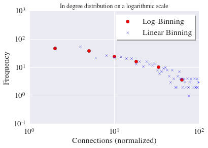

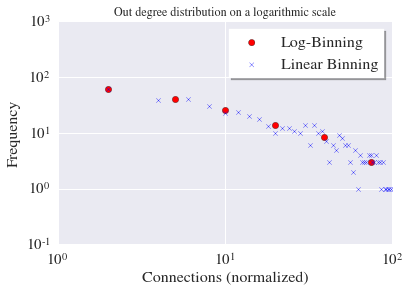

```
The most common degree is degree 2
```

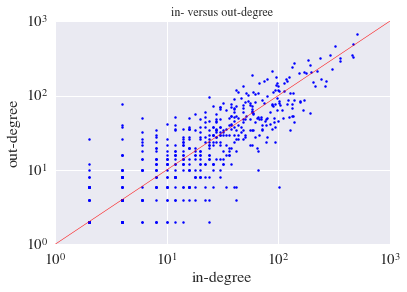

```python
network_analysis(G)
```

As we can see the progress is kind of linear, as it is clear that users with high in-degree also have a high out-degree. But, it is really clear that are also users with low in-degree but really big out-degree in comparison. This refers to users who make a lot of calls but they themselves they dont get called that much. We can see the same pattern in reverse and in a smaller scale for users who have a small out-going degree but a higher in-degree in comparison. These are the users who get called but they do not make a lot of calls.

```python
nx.write_gexf(G, "call_log_total2014_multidigraph.gexf")
```

```python
#we exract the Giant Connected Comoponent of our Directed Graph
Gcc=max(nx.weakly_connected_component_subgraphs(G), key = len)
```

```python
#we transform our GCC to an undireced graph
H = nx.MultiDiGraph.to_undirected(Gcc, reciprocal=False)
```

```python
#we exctract the betweenness centrality of our nodes
node_betweenness = nx.betweenness_centrality(Gcc)

#We calculate the top 5 users
top_5_betweenness = Counter(node_betweenness).most_common(5)
print "The top 5 users by betweenness centrality:"
for touple in top_5_betweenness:
    print touple[0]
```

```
The top 5 users by betweenness centrality:
221
263
176
401
578
```

The betweenness centrality shows that these users can always be found on the paths that lead to other users. That means that these users probablu act as "common friends" or bridges between different groups. Another interpretation might be that these users are more "famous".

```python
r = nx.degree_assortativity_coefficient(H)
print "The assortativity of the graph is r = ", r
```

```
The assortativity of the graph is r =  0.719594034313
```

The network is assortative. This means that high-degree users tend to link to other high-degree users, and low-degree users to other low-degree users.

### --------------- DiGraph ----------------------

```python
Z = nx.DiGraph()
```

```
The total number of nodes in the network is 565
The total number of links in the network is 1450
The average degree of the network is 5.13274336283
The median degree of the network is 4.0
The maximum degree is:  29
The minimum degree is:  1

The top 10 users by in-degree are:
221
15
280
485
4
13
401
466
37
52

The top 10 users by out-degree are:
4
100
263
15
221
466
485
378
13
37
The average in degree of the network is 2.56637168142
The median in degree of the network is 2.0
The maximum in degree is:  17
The average out degree of the network is 2.56637168142
The median out degree of the network is 2.0
The maximum out degree is:  14
```

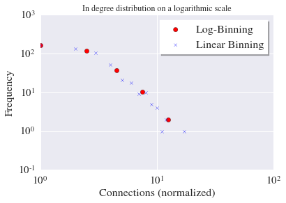

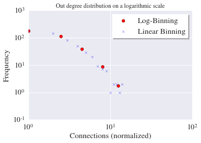

```
The most common degree is degree 1
```

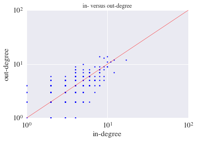

```python
network_analysis(Z)
```

```python
nx.write_gexf(Z, "call_log_total2014_digraph.gexf")
```

```python
#we exract the Giant Connected Comoponent of our Directed Graph
Gcc=max(nx.weakly_connected_component_subgraphs(Z), key = len)
```

```python
#we transform our GCC to an undireced graph
H = nx.DiGraph.to_undirected(Gcc, reciprocal=False)
```

```python
#we exctract the betweenness centrality of our nodes
node_betweenness = nx.betweenness_centrality(Gcc)

#We calculate the top 5 users
top_5_betweenness = Counter(node_betweenness).most_common(5)
print "The top 5 users by betweenness centrality:"
for touple in top_5_betweenness:
    print touple[0]
```

```
The top 5 users by betweenness centrality:
221
263
176
401
578
```

```python
r = nx.degree_assortativity_coefficient(H)
print "The assortativity of the graph is r = ", r
```

```
The assortativity of the graph is r =  0.211098433314
```